```python
import numpy as np
import pandas as pd
import matplotlib.pyplot as plt
import seaborn as sns
import math
import statistics

#pre-processing
from sklearn.impute import KNNImputer
from sklearn.preprocessing import StandardScaler

# model evaluation
from sklearn import metrics
from sklearn.metrics import accuracy_score
from sklearn.metrics import plot_confusion_matrix

# K-Means
from sklearn.cluster import KMeans
from sklearn.datasets import make_blobs
from scipy.spatial.distance import cdist
from matplotlib.patches import Ellipse

# random forest
from sklearn.ensemble import RandomForestClassifier, RandomForestRegressor, AdaBoostRegressor

# KNN
from sklearn.neighbors import KNeighborsClassifier

from warnings import simplefilter
simplefilter(action='ignore', category=FutureWarning)

import warnings
warnings.filterwarnings('ignore')

# decision tree
from sklearn import tree
from sklearn.tree import DecisionTreeClassifier, DecisionTreeRegressor

# model building
from sklearn.model_selection import train_test_split, GridSearchCV

# model evaluation
from sklearn.metrics import accuracy_score, mean_squared_error

# gradient boosting
from sklearn.ensemble import GradientBoostingClassifier, GradientBoostingRegressor

# set seed for reproducible results
RSEED = 10

# Dimension reduction
from sklearn.decomposition import TruncatedSVD
from sklearn.decomposition import PCA
```

# Section A

Data frames settings.

```python
df_country_complete = pd.read_csv('county_complete.csv')
df_president = pd.read_csv('1976-2020-president.csv')
df_house = pd.read_csv('1976-2020-house.csv')
df_senate = pd.read_csv('1976-2020-senate.csv')
df_Life_Expectancy = pd.read_csv('IHME_USA_LIFE_EXPECTANCY_1987_2007_Y2011M06D16.csv')
df_Economic = pd.read_csv('BCB-UDJIAD1.csv')
dow_jones_df = pd.read_csv('Dow Jones Industrial Average Historical Data 2.csv')
df_county_data_landarea = pd.read_csv('5296US_landarea.csv')
df_county_data_pop = pd.read_csv('5296US_pop.csv')
df_county_data_waterarea = pd.read_csv('5296US_waterarea.csv')
df_Life_Expectancy_xlsx = pd.read_excel('IHME_USA_LIFE_EXPECTANCY_1987_2007_Y2011M06D16.xlsx')
```

# merge country data csv files into one data frame

```python
result= pd.merge(left = df_county_data_landarea, right = df_county_data_pop, how = 'inner' , on = ['FIPS','State','County'])
df_county_data=pd.merge(left = result, right = df_county_data_waterarea, how = 'inner' , on = ['FIPS','State','County'])
df_county_data
```

|  | FIPS | State | County | Land Area | Date | Population | Water Area |
| --- | --- | --- | --- | --- | --- | --- | --- |
| 0 | 1001 | Alabama | Autauga | 1543.7 | 1990 | 34222 | 22.0 |
| 1 | 1003 | Alabama | Baldwin | 4135.0 | 1990 | 98280 | 1115.1 |
| 2 | 1005 | Alabama | Barbour | 2292.1 | 1990 | 25417 | 50.7 |
| 3 | 1007 | Alabama | Bibb | 1611.9 | 1990 | 16576 | 8.1 |
| 4 | 1009 | Alabama | Blount | 1672.3 | 1990 | 39248 | 12.9 |
| ... | ... | ... | ... | ... | ... | ... | ... |
| 2936 | 56037 | Wyoming | Sweetwater | 27003.0 | 1990 | 38823 | 170.0 |
| 2937 | 56039 | Wyoming | Teton | 10380.6 | 1990 | 11172 | 554.3 |
| 2938 | 56041 | Wyoming | Uinta | 5391.7 | 1990 | 18705 | 15.3 |
| 2939 | 56043 | Wyoming | Washakie | 5802.0 | 1990 | 8388 | 7.0 |
| 2940 | 56045 | Wyoming | Weston | 6210.6 | 1990 | 6518 | 5.7 |

2941 rows × 7 columns

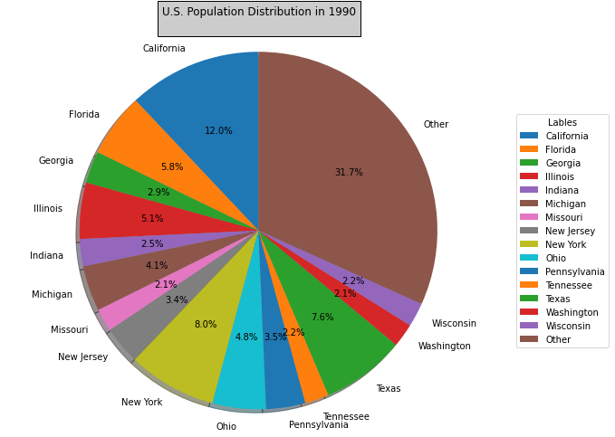

```python
df = df_county_data.groupby(by=['State','Date'],as_index=False).sum()

state_list = []
population_list = []
total_pop = sum(df['Population'].values.tolist())
other_pop = 0
for state, population in zip(df['State'].values.tolist(),df['Population'].values.tolist()):
    if((population *100 / total_pop) > 2):
        state_list.append(state)
        population_list.append(population)
    else:
        other_pop += population

state_list.append('Other')
population_list.append(other_pop)

labels = state_list

fig1, ax1 = plt.subplots(figsize=(10,8))
ax1.pie(population_list, labels=labels, autopct='%1.1f%%',
        shadow=True, startangle=90)
ax1.axis('equal')  # Equal aspect ratio ensures that pie is drawn as a circle.
ax1.legend(labels,
          title="Lables",
          loc="center left",
          bbox_to_anchor=(1, 0, 0.5, 1))
plt.title("U.S. Population Distribution in 1990\n", bbox={'facecolor':'0.8', 'pad':5})
plt.show()
```

## GeneralDemographicData

```python
df_country_complete.head()
```

|  | fips | state | name | pop2000 | pop2010 | pop2011 | pop2012 | pop2013 | pop2014 | pop2015 | ... | poverty_under_18_2019 | two_plus_races_2019 | unemployment_rate_2019 | uninsured_2019 | uninsured_65_and_older_2019 | uninsured_under_19_2019 | uninsured_under_6_2019 | veterans_2019 | white_2019 | white_not_hispanic_2019 |
| --- | --- | --- | --- | --- | --- | --- | --- | --- | --- | --- | --- | --- | --- | --- | --- | --- | --- | --- | --- | --- | --- |
| 0 | 1001 | Alabama | Autauga County | 43671.0 | 54571 | 55199.0 | 54927.0 | 54695.0 | 54864.0 | 54838.0 | ... | 23.2 | 2.2 | 3.5 | 7.1 | 0.0 | 1.7 | 1.7 | 12.6 | 76.8 | 74.6 |
| 1 | 1003 | Alabama | Baldwin County | 140415.0 | 182265 | 186534.0 | 190048.0 | 194736.0 | 199064.0 | 202863.0 | ... | 13.4 | 1.7 | 4.0 | 8.9 | 0.3 | 3.8 | 2.2 | 11.8 | 86.2 | 83.1 |
| 2 | 1005 | Alabama | Barbour County | 29038.0 | 27457 | 27351.0 | 27175.0 | 26947.0 | 26749.0 | 26264.0 | ... | 50.1 | 1.2 | 9.4 | 11.3 | 0.3 | 3.3 | 3.4 | 6.6 | 46.8 | 45.8 |
| 3 | 1007 | Alabama | Bibb County | 20826.0 | 22915 | 22745.0 | 22658.0 | 22503.0 | 22533.0 | 22561.0 | ... | NaN | 0.6 | 7.0 | 10.7 | 0.0 | 2.0 | 4.5 | 8.0 | 76.8 | 74.5 |
| 4 | 1009 | Alabama | Blount County | 51024.0 | 57322 | 57562.0 | 57595.0 | 57623.0 | 57546.0 | 57590.0 | ... | 18.4 | 1.6 | 3.1 | 10.8 | 0.2 | 5.9 | 6.1 | 7.7 | 95.5 | 86.9 |

5 rows × 188 columns

# Number of votes per state in df over time

```python
yearly_votes = df_president[['year','state','totalvotes']]\
.groupby(['year','state']).mean().reset_index()
display(yearly_votes)
```

|  | year | state | totalvotes |
| --- | --- | --- | --- |
| 0 | 1976 | ALABAMA | 1182850.0 |
| 1 | 1976 | ALASKA | 123574.0 |
| 2 | 1976 | ARIZONA | 742719.0 |
| 3 | 1976 | ARKANSAS | 767535.0 |
| 4 | 1976 | CALIFORNIA | 7803770.0 |
| ... | ... | ... | ... |
| 607 | 2020 | VIRGINIA | 4460524.0 |
| 608 | 2020 | WASHINGTON | 4087631.0 |
| 609 | 2020 | WEST VIRGINIA | 794652.0 |
| 610 | 2020 | WISCONSIN | 3298041.0 |
| 611 | 2020 | WYOMING | 278503.0 |

612 rows × 3 columns

# WE CAN SAY THAT THE NUMBER OF PEOPLE VOTING IS INCREASING

but not lineary

This change might be explained by increase in population number. Another explantaion might be that more people were able to vote due to sociological changes in politics like voting rights.

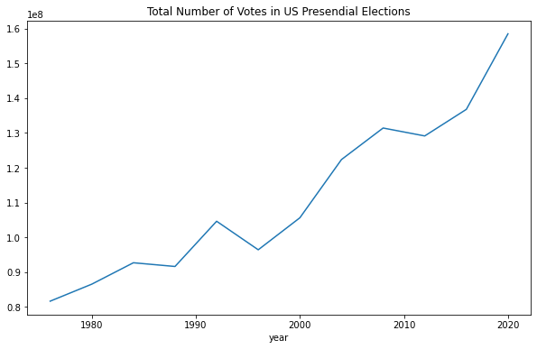

```python
yearly_votes.groupby('year').sum()\
.plot(figsize=(10,6), legend=False,
title='Total Number of Votes in US Presendial Elections')
plt.show()
```

```python
df_Life_Expectancy_xlsx
```

|  | fips | State | County | Year | Male life expectancy (years) | Years behind international frontier (male) | Female life expectancy (years) | Years behind international frontier (female) | White male life expectancy (years) | White female life expectancy (years) | ... | Closest ranked countries for male life expectancy (lower) | Closest ranked countries for female life expectancy (lower) | Rank (male) | Rank (female) | Male life expectancy change 1987 to 2007 (years) | Female life expectancy change 1987 to 2007 (years) | Male life expectancy change 1987 to 1997 (years) | Female life expectancy change 1987 to 1997 (years) | Male life expectancy change 1997 to 2007 (years) | Female life expectancy change 1997 to 2007 (years) |
| --- | --- | --- | --- | --- | --- | --- | --- | --- | --- | --- | --- | --- | --- | --- | --- | --- | --- | --- | --- | --- | --- |
| 0 | 1001 | ALABAMA | AUTAUGA | 1987 | 69.2 | 32 | 77.4 | 12 | 70.3 | 78.5 | ... | Albania,Bahrain,Guam,Jamaica,Macedonia, the Fo... | Guadeloupe,Israel,Malta,Montenegro,Portugal | 2684 | 2661 | 3.7 | 0.6 | 1.5 | 0.8 | 2.2 | -0.2 |
| 1 | 1001 | ALABAMA | AUTAUGA | 1988 | 69.3 | 32 | 77.3 | 14 | 70.5 | 78.4 | ... | Albania,Jamaica,Macedonia, the Former Yugoslav... | Barbados,Cuba,Mayotte,Reunion,Slovenia | 2646 | 2691 | 3.7 | 0.6 | 1.5 | 0.8 | 2.2 | -0.2 |
| 2 | 1001 | ALABAMA | AUTAUGA | 1989 | 69.8 | 25 | 77.5 | 14 | 71.0 | 78.6 | ... | Albania,Bahrain,Guam,Macedonia, the Former Yug... | Barbados,Mayotte,Reunion,Singapore,Slovenia | 2522 | 2637 | 3.7 | 0.6 | 1.5 | 0.8 | 2.2 | -0.2 |
| 3 | 1001 | ALABAMA | AUTAUGA | 1990 | 69.7 | 27 | 77.7 | 14 | 71.0 | 78.7 | ... | Albania,French Guiana,Macedonia, the Former Yu... | Barbados,Mayotte,Netherlands Antilles,Reunion,... | 2585 | 2590 | 3.7 | 0.6 | 1.5 | 0.8 | 2.2 | -0.2 |
| 4 | 1001 | ALABAMA | AUTAUGA | 1991 | 70.0 | 25 | 77.7 | 15 | 71.2 | 78.8 | ... | French Guiana,Macedonia, the Former Yugoslav R... | Barbados,Kuwait,Netherlands Antilles,Singapore... | 2534 | 2616 | 3.7 | 0.6 | 1.5 | 0.8 | 2.2 | -0.2 |
| ... | ... | ... | ... | ... | ... | ... | ... | ... | ... | ... | ... | ... | ... | ... | ... | ... | ... | ... | ... | ... | ... |
| 66082 | 56045 | WYOMING | WESTON | 2003 | 75.0 | 12 | 80.5 | 14 | 74.9 | 80.5 | ... | Brunei Darussalam,Chile,Finland,Korea, Republi... | Cuba,Denmark,Greece,Mayotte,Reunion | 957 | 749 | 3.5 | 1.7 | 2.0 | 0.2 | 1.5 | 1.5 |
| 66083 | 56045 | WYOMING | WESTON | 2004 | 75.4 | 11 | 80.6 | 15 | 75.4 | 80.5 | ... | Chile,Denmark,Finland,Guadeloupe,Virgin Island... | Cuba,Denmark,Kuwait,Mayotte,Reunion | 779 | 808 | 3.5 | 1.7 | 2.0 | 0.2 | 1.5 | 1.5 |
| 66084 | 56045 | WYOMING | WESTON | 2005 | 75.4 | 12 | 80.7 | 15 | 75.4 | 80.7 | ... | Brunei Darussalam,Chile,Korea, Republic of,Por... | Cuba,Denmark,French Guiana,Mayotte,Reunion | 883 | 742 | 3.5 | 1.7 | 2.0 | 0.2 | 1.5 | 1.5 |
| 66085 | 56045 | WYOMING | WESTON | 2006 | 75.6 | 12 | 81.1 | 14 | 75.6 | 81.1 | ... | Brunei Darussalam,Chile,Korea, Republic of,Por... | Cuba,Denmark,Greece,Mayotte,Reunion | 843 | 563 | 3.5 | 1.7 | 2.0 | 0.2 | 1.5 | 1.5 |
| 66086 | 56045 | WYOMING | WESTON | 2007 | 75.9 | 12 | 81.5 | 13 | 75.9 | 81.5 | ... | Brunei Darussalam,Chile,Korea, Republic of,Por... | Channel Islands,Greece,Malta,United Kingdom,Un... | 727 | 393 | 3.5 | 1.7 | 2.0 | 0.2 | 1.5 | 1.5 |

66087 rows × 24 columns

# PRE PROCESSING FOR LIFE EXPACTANCY DATA

```python
# pre processing towards section B {clustring}

df_Life_Expectancy_xlsx_state_and_County = df_Life_Expectancy_xlsx[df_Life_Expectancy_xlsx['State'].isin(['CALIFORNIA','FLORIDA','SOUTH DAKOTA','WYOMING'])]
df_Life_Expectancy_xlsx_state_and_County[['State','County']]
df_Life_Expectancy_xlsx_state_and_County['State'] = df_Life_Expectancy_xlsx_state_and_County['State'].str.capitalize()  # capital letters only
df_Life_Expectancy_xlsx_state_and_County['County'] = df_Life_Expectancy_xlsx_state_and_County['County'].str.capitalize() # capital letters only
```

## LifeExpectancyData

We conducted an expiriment to get a better feel for the data. Took the earliest year in the data set and the latest year in the data set.

for those years we checked the life expactancy for males and females.

```python
cols = [3,4,6,8,9]
life_expactancy_df_test = df_Life_Expectancy[df_Life_Expectancy.columns[cols]]
life_expactancy_df_alabama_1987=life_expactancy_df_test.loc[life_expactancy_df_test['Year'] == 1987]
male_avg_death_age_1987 = life_expactancy_df_alabama_1987['Male life expectancy (years)'].mean()
female_avg_death_age_1987 = life_expactancy_df_alabama_1987['Female life expectancy (years)'].mean()


print('### IN ALABAMA AT YEAR 1987 ###\n')
print(f'MALES LIVES ON AVG UNTIL {male_avg_death_age_1987} YEARS OLD')
print(f'FEMALES LIVES ON AVG UNTIL {female_avg_death_age_1987} YEARS OLD')
print('\n\n')
print(f'FEMALES LIVE {female_avg_death_age_1987-male_avg_death_age_1987} YEARS MORE THAN MAN ON AVG\n\n')
```

```
### IN ALABAMA AT YEAR 1987 ###

MALES LIVES ON AVG UNTIL 71.05583095011133 YEARS OLD
FEMALES LIVES ON AVG UNTIL 78.51591992373685 YEARS OLD



FEMALES LIVE 7.460088973625517 YEARS MORE THAN MAN ON AVG
```

```python
life_expactancy_df_alabama_2007=life_expactancy_df_test.loc[life_expactancy_df_test['Year'] == 2007]
male_avg_death_age_2007 = life_expactancy_df_alabama_2007['Male life expectancy (years)'].mean()
female_avg_death_age_2007 = life_expactancy_df_alabama_2007['Female life expectancy (years)'].mean()

print('### IN ALABAMA AT YEAR 2007 ###\n')
print(f'MALES LIVES ON AVG UNTIL {male_avg_death_age_2007} YEARS OLD')
print(f'FEMALES LIVES ON AVG UNTIL {female_avg_death_age_2007} YEARS OLD\n\n')
print(f'FEMALES LIVE {female_avg_death_age_2007-male_avg_death_age_2007} YEARS MORE THAN MAN ON AVG\n\n')
```

```
### IN ALABAMA AT YEAR 2007 ###

MALES LIVES ON AVG UNTIL 74.15548141086738 YEARS OLD
FEMALES LIVES ON AVG UNTIL 79.71458531935156 YEARS OLD


FEMALES LIVE 5.559103908484175 YEARS MORE THAN MAN ON AVG
```

# We conducted another expiriment to understand if there is such different between white men and white women life expactancy.

```python
# MALES 1987
life_expactancy_df_alabama_1987=life_expactancy_df_test.loc[life_expactancy_df_test['Year'] == 1987]
white_male_avg_death_age_1987 = life_expactancy_df_alabama_1987['White male life expectancy (years)'].mean()
print('### IN ALABAMA AT YEAR 1987 ###\n')
print(f'WHITE MALES LIVES ON AVG UNTIL {white_male_avg_death_age_1987} YEARS OLD\n\n')

# MALES 2007
life_expactancy_df_alabama_1987=life_expactancy_df_test.loc[life_expactancy_df_test['Year'] == 2007]
white_male_avg_death_age_1987 = life_expactancy_df_alabama_1987['White male life expectancy (years)'].mean()
print('### IN ALABAMA AT YEAR 2007 ###\n')
print(f'WHITE MALES LIVES ON AVG UNTIL {white_male_avg_death_age_1987} YEARS OLD\n\n')


# FEMALES 1987
life_expactancy_df_alabama_1987=life_expactancy_df_test.loc[life_expactancy_df_test['Year'] == 1987]
white_male_avg_death_age_1987 = life_expactancy_df_alabama_1987['White female life expectancy (years)'].mean()
print('### IN ALABAMA AT YEAR 1987 ###\n')
print(f'WHITE FEMALES LIVES ON AVG UNTIL {white_male_avg_death_age_1987} YEARS OLD\n\n')

# FEMALES 2007
life_expactancy_df_alabama_1987=life_expactancy_df_test.loc[life_expactancy_df_test['Year'] == 2007]
white_male_avg_death_age_1987 = life_expactancy_df_alabama_1987['White female life expectancy (years)'].mean()
print('### IN ALABAMA AT YEAR 2007 ###\n')
print(f'WHITE FEMALES LIVES ON AVG UNTIL {white_male_avg_death_age_1987} YEARS OLD\n\n')
```

```
### IN ALABAMA AT YEAR 1987 ###

WHITE MALES LIVES ON AVG UNTIL 71.48134731490296 YEARS OLD


### IN ALABAMA AT YEAR 2007 ###

WHITE MALES LIVES ON AVG UNTIL 74.57432475373405 YEARS OLD


### IN ALABAMA AT YEAR 1987 ###

WHITE FEMALES LIVES ON AVG UNTIL 78.886526850969 YEARS OLD


### IN ALABAMA AT YEAR 2007 ###

WHITE FEMALES LIVES ON AVG UNTIL 80.03314267556426 YEARS OLD
```

# We can understand from the graph below that the life expactancy of males increased throughout the years.

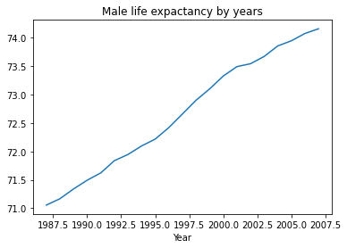

```python
#MALE LIFE EXC BY YEAR
avg_life_of_men_by_years = life_expactancy_df_test.copy()
male_life_exc_by_years=avg_life_of_men_by_years.groupby(['Year']).mean()['Male life expectancy (years)']
# display(male_life_exc_by_years)
male_life_exc_by_years.plot.line(x='year',y='age')
plt.title('Male life expactancy by years')
plt.show()
```

# We can see that life expactancy of females is not linear as males life expactancy is.

# We might suggest to check what happend between years 2002 to 2005

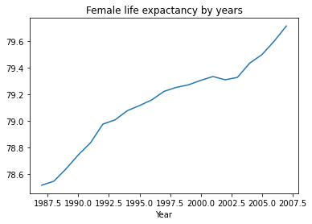

```python
#FEMALE LIFE EXC BY YEAR
avg_life_of_men_by_years = life_expactancy_df_test.copy()
male_life_exc_by_years=avg_life_of_men_by_years.groupby(['Year']).mean()['Female life expectancy (years)']
# display(male_life_exc_by_years)
male_life_exc_by_years.plot.line(x='year',y='age')
plt.title('Female life expactancy by years')
plt.show()
```

## EconomicData

Dow Jones, or more precisely, Dow Jones & Company, is one of the world's largest business and financial news companies

```python
dow_jones_df
```

|  | Date | Price | Open | High | Low | Vol. | Change % |
| --- | --- | --- | --- | --- | --- | --- | --- |
| 0 | Dec 31, 2019 | 28,538.44 | 28,414.64 | 28,547.35 | 28,376.49 | 193.34M | 0.27% |
| 1 | Dec 30, 2019 | 28,462.14 | 28,654.76 | 28,664.69 | 28,428.98 | 185.07M | -0.64% |
| 2 | Dec 27, 2019 | 28,645.26 | 28,675.34 | 28,701.66 | 28,608.98 | 184.93M | 0.08% |
| 3 | Dec 26, 2019 | 28,621.39 | 28,539.46 | 28,624.10 | 28,535.15 | 155.97M | 0.37% |
| 4 | Dec 24, 2019 | 28,515.45 | 28,572.57 | 28,576.80 | 28,503.21 | 95.29M | -0.13% |
| ... | ... | ... | ... | ... | ... | ... | ... |
| 2761 | Jan 09, 2009 | 8,599.18 | 8,738.80 | 8,800.45 | 8,541.75 | - | -1.64% |
| 2762 | Jan 08, 2009 | 8,742.46 | 8,769.94 | 8,807.14 | 8,593.52 | - | -0.31% |
| 2763 | Jan 07, 2009 | 8,769.70 | 8,996.94 | 8,996.94 | 8,690.45 | - | -2.72% |
| 2764 | Jan 06, 2009 | 9,015.10 | 8,954.57 | 9,175.19 | 8,868.07 | - | 0.69% |
| 2765 | Jan 05, 2009 | 8,952.89 | 9,027.13 | 9,093.47 | 8,841.70 | - | -0.91% |

2766 rows × 7 columns

# PRE PROCESSING FOR THE DOW JONES DATA

changed the strings to be easy to use {without any commas or % signs}.

```python
"""PRE PROCESSING -- REMOVE COMAS (,) AND PERCENTAGE (%)"""
dow_jones_df['Price']=dow_jones_df['Price'].str.replace(',','')
dow_jones_df['Change %']=dow_jones_df['Change %'].str.replace('%','')

DJ_Price_date = pd.DataFrame(dow_jones_df,columns=['Price','Date','Change %'])
DJ_Price_date['YEAR'] = pd.DatetimeIndex(DJ_Price_date['Date']).year
print(DJ_Price_date)
```

```
         Price          Date Change %  YEAR
0     28538.44  Dec 31, 2019     0.27  2019
1     28462.14  Dec 30, 2019    -0.64  2019
2     28645.26  Dec 27, 2019     0.08  2019
3     28621.39  Dec 26, 2019     0.37  2019
4     28515.45  Dec 24, 2019    -0.13  2019
...        ...           ...      ...   ...
2761   8599.18  Jan 09, 2009    -1.64  2009
2762   8742.46  Jan 08, 2009    -0.31  2009
2763   8769.70  Jan 07, 2009    -2.72  2009
2764   9015.10  Jan 06, 2009     0.69  2009
2765   8952.89  Jan 05, 2009    -0.91  2009

[2766 rows x 4 columns]
```

# We suggest a metric to understand how stable is the stock market in a current year.

each point in the graph is a change by % in a day in that year.

if we notice a big cluster around change = 0% we can see that overall the year was pretty stable.

# PRE PROCESSING

changed data types of the columns to be usable for the next sections and for plotting.

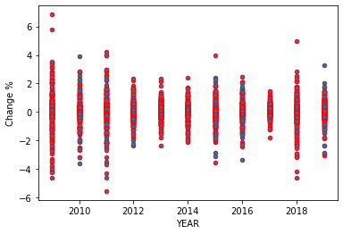

```python
"""PRE PROCESSING -- TURN COLUMNS NUMBERS FROM STRING TO FLOAT"""
DJ_Price_date['Price'] = DJ_Price_date['Price'].astype('float')
DJ_Price_date['YEAR'] = DJ_Price_date['YEAR'].astype('float')
DJ_Price_date['Change %'] = DJ_Price_date['Change %'].astype('float')

"""change in % by year - if the points cluster was above 0 then the price went up'"""
DJ_Price_date.plot.scatter(x="YEAR", y="Change %",edgecolors= 'red')
plt.show()
```

```python
df_Economic.head()
```

|  | Date | Value |
| --- | --- | --- |
| 0 | 2016-04-15 | 17897.46 |
| 1 | 2016-04-14 | 17926.43 |
| 2 | 2016-04-13 | 17908.28 |
| 3 | 2016-04-12 | 17721.25 |
| 4 | 2016-04-11 | 17556.41 |

# Estimation of population in Wyoming,South Dakota,California,Florida

[figure not shown]

```python
 # pop20** – estimated population in the year 20**.


from matplotlib.figure import Figure
df = df_country_complete.groupby(by=['state'],as_index=False).sum()
df = df[['state','pop2000','pop2010','pop2011','pop2012','pop2013','pop2014','pop2015','pop2016','pop2017']]
df = df[df['state'].isin(['Wyoming','South Dakota','California','Florida'])]

years = [2000,2010,2011,2012,2013,2014,2015,2016,2017]
list_pop =[]
for row in df.itertuples():
    list_pop.append([row[2],row[3],row[4],row[5],row[6],row[7],row[8],row[9],row[10]])

fig = plt.figure(figsize =(5, 4))
ax1 = fig.add_axes([0.1, 0.1, 0.8, 0.8],title = 'Wyoming')
ax2 = fig.add_axes([1, 0.1, 0.8, 0.8],title = 'South dakota')
ax3 = fig.add_axes([2, 0.1, 0.8, 0.8],title ='California')
ax4 = fig.add_axes([3, 0.1, 0.8, 0.8],title ='Florida')


y=years
ax1.plot(y, list_pop[0])
ax2.plot(y, list_pop[1])
ax3.plot(y, list_pop[2])
ax4.plot(y, list_pop[3])

plt.show()
```

# understanding the data --> amout of missing values

```python
df_Life_Expectancy_xlsx.isnull().sum()
```

```
fips                                                                0
State                                                               0
County                                                              0
Year                                                                0
Male life expectancy (years)                                        0
Years behind international frontier (male)                          0
Female life expectancy (years)                                      0
Years behind international frontier (female)                        0
White male life expectancy (years)                                  0
White female life expectancy (years)                                0
Black male life expectancy (years)                              50593
Black female life expectancy (years)                            47725
Closest ranked countries for male life expectancy (higher)         96
Closest ranked countries for female life expectancy (higher)       11
Closest ranked countries for male life expectancy (lower)           0
Closest ranked countries for female life expectancy (lower)         0
Rank (male)                                                         0
Rank (female)                                                       0
Male life expectancy change 1987 to 2007 (years)                    0
Female life expectancy change 1987 to 2007 (years)                  0
Male life expectancy change 1987 to 1997 (years)                    0
Female life expectancy change 1987 to 1997 (years)                  0
Male life expectancy change 1997 to 2007 (years)                    0
Female life expectancy change 1997 to 2007 (years)                  0
dtype: int64
```

```python
df_county_data_landarea.isnull().sum()
```

```
FIPS         0
State        0
County       0
Land Area    0
dtype: int64
```

# check null items in the merged table of the country data.

```python
df_county_data.isnull().sum()
```

```
FIPS            0
State           0
County          0
Land Area       0
Date            0
Population      0
Water Area    183
dtype: int64
```

```python
df_country_complete.isnull().sum()
```

```
fips                       0
state                      0
name                       0
pop2000                    3
pop2010                    0
                          ..
uninsured_under_19_2019    0
uninsured_under_6_2019     0
veterans_2019              0
white_2019                 0
white_not_hispanic_2019    0
Length: 188, dtype: int64
```

work with table copies

```python
df_Life_Expectancy_xlsx_copy = df_Life_Expectancy_xlsx.copy(deep=True)
df_country_complete_copy = df_country_complete.copy(deep=True)
df_county_data_landarea_copy = df_county_data_landarea.copy(deep=True)
df_county_data_copy = df_county_data.copy(deep=True)
```

Dimensionality reduction --> Feature selection We found out that:

Missing values:

Black male life expectancy (years) --> 50593

Black female life expectancy (years) --> 47725

we will remove those columns

```python
# will find what features are useless.

# If some columns has missing data by more than 50% , we drop those columns.
# for that task we will define a threshold that will be initialized to be the length of the column devided by 2 {50%}.

# pandas.DataFrame.dropna --> Remove missing values.

print('columns before dropping missing values columns:')
print(df_Life_Expectancy_xlsx_copy.columns)
print('\n\n')


# print('\ndata frame df_Life_Expectancy_xlsx_copy')
# print('amount of columns before change ')
# print(len(df_Life_Expectancy_xlsx_copy.columns))
df_Life_Expectancy_xlsx_copy.dropna(thresh=len(df_Life_Expectancy_xlsx_copy.columns.tolist())/3, axis=0, inplace=True)
# print('amount of columns after change ')
# print(len(df_Life_Expectancy_xlsx_copy.columns))




# print('\ndata frame df_Life_Expectancy_xlsx_copy')
# print('amount of columns before change ')
# print(len(df_country_complete_copy.columns))
df_country_complete_copy.dropna(thresh=len(df_country_complete_copy.columns.tolist())/2, axis=0, inplace=True)
# print('amount of columns after change ')
# print(len(df_country_complete_copy.columns))


# print('\ndata frame df_Life_Expectancy_xlsx_copy')
# print('amount of columns before change ')
# print(len(df_county_data_landarea_copy.columns))
df_county_data_landarea_copy.dropna(thresh=len(df_county_data_landarea_copy.columns.tolist())/2, axis=0, inplace=True)
# print('amount of columns after change ')
# print(len(df_county_data_landarea_copy.columns))

# print('\ndata frame df_county_data_copy')
# print('amount of columns before change ')
# print(len(df_county_data_copy.columns))
df_county_data_copy.dropna(thresh=len(df_county_data_copy.columns.tolist())/2, axis=0, inplace=True)
# print('amount of columns after change ')
# print(len(df_county_data_copy.columns))

df_Life_Expectancy_xlsx_copy.drop(['Black male life expectancy (years)','Black female life expectancy (years)'], axis=1, inplace=True)
print('columns after dropping missing values columns:')
print(df_Life_Expectancy_xlsx_copy.columns)
```

```
columns before dropping missing values columns:
Index(['fips', 'State', 'County', 'Year', 'Male life expectancy (years)',
       'Years behind international frontier (male)',
       'Female life expectancy (years)',
       'Years behind international frontier (female)',
       'White male life expectancy (years)',
       'White female life expectancy (years)',
       'Black male life expectancy (years)',
       'Black female life expectancy (years)',
       'Closest ranked countries for male life expectancy (higher)',
       'Closest ranked countries for female life expectancy (higher)',
       'Closest ranked countries for male life expectancy (lower)',
       'Closest ranked countries for female life expectancy (lower)',
       'Rank (male)', 'Rank (female)',
       'Male life expectancy change 1987 to 2007 (years)',
       'Female life expectancy change 1987 to 2007 (years)',
       'Male life expectancy change 1987 to 1997 (years)',
       'Female life expectancy change 1987 to 1997 (years)',
       'Male life expectancy change 1997 to 2007 (years)',
       'Female life expectancy change 1997 to 2007 (years)'],
      dtype='object')



columns after dropping missing values columns:
Index(['fips', 'State', 'County', 'Year', 'Male life expectancy (years)',
       'Years behind international frontier (male)',
       'Female life expectancy (years)',
       'Years behind international frontier (female)',
       'White male life expectancy (years)',
       'White female life expectancy (years)',
       'Closest ranked countries for male life expectancy (higher)',
       'Closest ranked countries for female life expectancy (higher)',
       'Closest ranked countries for male life expectancy (lower)',
       'Closest ranked countries for female life expectancy (lower)',
       'Rank (male)', 'Rank (female)',
       'Male life expectancy change 1987 to 2007 (years)',
       'Female life expectancy change 1987 to 2007 (years)',
       'Male life expectancy change 1987 to 1997 (years)',
       'Female life expectancy change 1987 to 1997 (years)',
       'Male life expectancy change 1997 to 2007 (years)',
       'Female life expectancy change 1997 to 2007 (years)'],
      dtype='object')
```

We apply one hot encoding for the state column, Preperation for the ML model.

```python
state_life_exp = [state.capitalize() for state in set(df_Life_Expectancy_xlsx_copy['State'].tolist())]
state_country_complete = [state.capitalize() for state in set(df_country_complete_copy['state'].tolist())]
state_data_landarea = [state.capitalize() for state in set(df_county_data_landarea_copy['State'].tolist())]
state_county_data = [state.capitalize() for state in set(df_county_data_copy['State'].tolist())]

states_df_1 = pd.DataFrame(columns = state_life_exp)
states_df_2 = pd.DataFrame(columns = state_country_complete)
states_df_3 = pd.DataFrame(columns = state_data_landarea)
states_df_4 = pd.DataFrame(columns = state_county_data)

df_Life_Expectancy_xlsx_copy = pd.concat([df_Life_Expectancy_xlsx_copy, states_df_1], axis=1)
df_country_complete_copy = pd.concat([df_country_complete_copy, states_df_2], axis=1)
df_county_data_landarea_copy = pd.concat([df_county_data_landarea_copy, states_df_3], axis=1)
df_county_data_copy = pd.concat([df_county_data_copy, states_df_4], axis=1)

#fill the columns

for row in df_Life_Expectancy_xlsx_copy.itertuples():
    df_Life_Expectancy_xlsx_copy.at[row[0],str(row[2].capitalize())]=1
for state in state_life_exp:
    df_Life_Expectancy_xlsx_copy[state.capitalize()].replace(np.NaN, 0, inplace=True)

for row in df_country_complete_copy.itertuples():
    df_country_complete_copy.at[row[0],str(row[2].capitalize())]=1
for state in state_country_complete:
    df_country_complete_copy[state.capitalize()].replace(np.NaN, 0, inplace=True)


for row in df_county_data_landarea_copy.itertuples():
    df_county_data_landarea_copy.at[row[0],str(row[2].capitalize())]=1
for state in state_data_landarea:
    df_county_data_landarea_copy[state.capitalize()].replace(np.NaN, 0, inplace=True)


for row in df_county_data_copy.itertuples():
    df_county_data_copy.at[row[0],str(row[2].capitalize())]=1
for state in state_county_data:
    df_county_data_copy[state.capitalize()].replace(np.NaN, 0, inplace=True)
```

# choose only california , florida, south dakota and wyoming

# because we used one hot encoding --> we determine if those countries are in the df by checking if their values are equal to 1.

```python
df_Life_Expectancy_xlsx_copy = df_Life_Expectancy_xlsx_copy[(df_Life_Expectancy_xlsx_copy['California']==1) |
                                                            (df_Life_Expectancy_xlsx_copy['Florida']==1) |
                                                             (df_Life_Expectancy_xlsx_copy['South dakota']==1) |
                                                             (df_Life_Expectancy_xlsx_copy['Wyoming']==1)]

df_country_complete_copy = df_country_complete_copy[(df_country_complete_copy['California']==1 ) |
                                                            (df_country_complete_copy['Florida']==1) |
                                                             (df_country_complete_copy['South dakota']==1) |
                                                             (df_country_complete_copy['Wyoming']==1)]

df_county_data_landarea_copy = df_county_data_landarea_copy[(df_county_data_landarea_copy['California']==1 ) |
                                                            (df_county_data_landarea_copy['Florida']==1) |
                                                             (df_county_data_landarea_copy['South dakota']==1) |
                                                             (df_county_data_landarea_copy['Wyoming']==1)]

df_county_data_copy = df_county_data_copy[(df_county_data_copy['California']==1 ) |
                                                            (df_county_data_copy['Florida']==1) |
                                                             (df_county_data_copy['South dakota']==1) |
                                                             (df_county_data_copy['Wyoming']==1)]
```

```python
states = ['California','Florida','South dakota','Wyoming']
for i in states:
    state_life_exp.remove(i)
    state_country_complete.remove(i)
    state_data_landarea.remove(i)
    state_county_data.remove(i)

df_Life_Expectancy_xlsx_copy.drop(state_life_exp, axis=1, inplace=True)
df_country_complete_copy.drop(state_country_complete, axis=1, inplace=True)
df_county_data_landarea_copy.drop(state_data_landarea, axis=1, inplace=True)
df_county_data_copy.drop(state_county_data, axis=1, inplace=True)
```

One-Hot Encoding for County column

```python
Countys_list = df_country_complete_copy['name'].tolist()
for i in range(len(Countys_list)):
    if('County' in Countys_list[i]):
        Countys_list[i] = Countys_list[i][:len(Countys_list[i])-7]
df_country_complete_copy['County'] = Countys_list
```

```python
County_life_exp = [county.capitalize() for county in set(df_Life_Expectancy_xlsx_copy['County'].tolist())]
County_country_complete = [county.capitalize() for county in set(df_country_complete_copy['County'].tolist())]
County_data_landarea = [county.capitalize() for county in set(df_county_data_landarea_copy['County'].tolist())]
County_county_data = [county.capitalize() for county in set(df_county_data_copy['County'].tolist())]

County_df_1 = pd.DataFrame(columns = County_life_exp)
County_df_2 = pd.DataFrame(columns = County_country_complete)
County_df_3 = pd.DataFrame(columns = County_data_landarea)
County_df_4 = pd.DataFrame(columns = County_county_data)

df_Life_Expectancy_xlsx_copy = pd.concat([df_Life_Expectancy_xlsx_copy, County_df_1], axis=1)
df_country_complete_copy = pd.concat([df_country_complete_copy, County_df_2], axis=1)
df_county_data_landarea_copy = pd.concat([df_county_data_landarea_copy, County_df_3], axis=1)
df_county_data_copy = pd.concat([df_county_data_copy, County_df_4], axis=1)

#fill the columns

for row in df_Life_Expectancy_xlsx_copy.itertuples(): # put 1 on the current store column
    df_Life_Expectancy_xlsx_copy.at[row[0],str(row[3]).capitalize()]=1
for County in County_life_exp:
    df_Life_Expectancy_xlsx_copy[County].replace(np.NaN, 0, inplace=True)

for row in df_country_complete_copy.itertuples(): # put 1 on the current store column
    df_country_complete_copy.at[row[0],str(row[240]).capitalize()]=1
for County in County_country_complete:
    df_country_complete_copy[County].replace(np.NaN, 0, inplace=True)


for row in df_county_data_landarea_copy.itertuples(): # put 1 on the current store column
    df_county_data_landarea_copy.at[row[0],str(row[3]).capitalize()]=1
for County in County_data_landarea:
    df_county_data_landarea_copy[County].replace(np.NaN, 0, inplace=True)


for row in df_county_data_copy.itertuples(): # put 1 on the current store column
    df_county_data_copy.at[row[0],str(row[3]).capitalize()]=1
for County in County_county_data:
    df_county_data_copy[County].replace(np.NaN, 0, inplace=True)
```

```python
# We drop County and name columns because they not necessary at this moment

df_Life_Expectancy_xlsx_copy.drop(['State','County'], axis=1, inplace=True)
df_country_complete_copy.drop(['state','name','County'], axis=1, inplace=True)
df_county_data_landarea_copy.drop(['State','County'], axis=1, inplace=True)
df_county_data_copy.drop(['State','County'], axis=1, inplace=True)
```

```python
# we got 50+ string on this colums, so now 100 means 50+
df_Life_Expectancy_xlsx_copy['Years behind international frontier (male)'].replace('50+', 100, inplace=True)
df_Life_Expectancy_xlsx_copy['Years behind international frontier (female)'].replace('50+', 100, inplace=True)

df_Life_Expectancy_xlsx_copy['Years behind international frontier (male)'] = pd.to_numeric(df_Life_Expectancy_xlsx_copy['Years behind international frontier (male)'],downcast='float')
df_Life_Expectancy_xlsx_copy['Years behind international frontier (female)'] = pd.to_numeric(df_Life_Expectancy_xlsx_copy['Years behind international frontier (female)'],downcast='float')
```

```python
df_Life_Expectancy_xlsx_copy.drop(['Closest ranked countries for male life expectancy (lower)','Closest ranked countries for female life expectancy (higher)','Closest ranked countries for male life expectancy (lower)','Closest ranked countries for female life expectancy (lower)','Closest ranked countries for male life expectancy (higher)'], axis=1, inplace=True)
```

```python
# Imputation for completing missing values using k-Nearest Neighbors.

imputer = KNNImputer(n_neighbors=5, weights="distance")
imputed = imputer.fit_transform(df_Life_Expectancy_xlsx_copy)

# replace values in the dataset with new imputed values
df_Life_Expectancy_xlsx_copy[df_Life_Expectancy_xlsx_copy.columns] = imputed
df_Life_Expectancy_xlsx_copy.isna().sum()
```

```
fips                                          0
Year                                          0
Male life expectancy (years)                  0
Years behind international frontier (male)    0
Female life expectancy (years)                0
                                             ..
Lafayette                                     0
Converse                                      0
Natrona                                       0
Indian river                                  0
Sierra                                        0
Length: 225, dtype: int64
```

```python
df_country_complete_copy.replace({'none':None}, inplace=True)
df_country_complete_copy.replace({'NA':None}, inplace=True)
df_country_complete_copy['uninsured_age_under_6_2017'].replace('-', None, inplace=True)

df_country_complete_copy.drop(['smoking_ban_2010'], axis=1, inplace=True)
```

```python
imputer = KNNImputer(n_neighbors=5, weights="distance")
imputed = imputer.fit_transform(df_country_complete_copy)

# replace values in the dataset with new imputed values
df_country_complete_copy[df_country_complete_copy.columns] = imputed
df_country_complete_copy.isna().sum()
```

```
fips        0
pop2000     0
pop2010     0
pop2011     0
pop2012     0
           ..
Goshen      0
Volusia     0
Teton       0
Hernando    0
Nan         0
Length: 395, dtype: int64
```

```python
imputer = KNNImputer(n_neighbors=5, weights="distance")
imputed = imputer.fit_transform(df_county_data_landarea_copy)

# replace values in the dataset with new imputed values
df_county_data_landarea_copy[df_county_data_landarea_copy.columns] = imputed
df_county_data_landarea_copy.isna().sum()
```

```
FIPS            0
Land Area       0
Florida         0
Wyoming         0
South dakota    0
               ..
Trinity         0
Goshen          0
Volusia         0
Teton           0
Hernando        0
Length: 211, dtype: int64
```

```python
imputer = KNNImputer(n_neighbors=5, weights="distance")
imputed = imputer.fit_transform(df_county_data_copy)

# replace values in the dataset with new imputed values
df_county_data_copy[df_county_data_copy.columns] = imputed
df_county_data_copy.isna().sum()
```

```
FIPS          0
Land Area     0
Date          0
Population    0
Water Area    0
             ..
Trinity       0
Goshen        0
Volusia       0
Teton         0
Hernando      0
Length: 206, dtype: int64
```

# Section B

```python
df_Life_Expectancy_xlsx_copy.drop(['Female life expectancy (years)','White male life expectancy (years)','Rank (female)'], axis=1, inplace=True)
list_to_remove= ['pop2000','pop2010','pop2011','pop2012','pop2013','pop2014','pop2015','pop2016',
                              'veterans_2010','housing_units_2010','households_2010','households_2017','sales_2007','civilian_labor_force_2007',
                              'civilian_labor_force_2008','civilian_labor_force_2009','employed_2007','employed_2008','employed_2009',
                              'unemployed_2007','unemployed_2008','unemployed_2009','civilian_labor_force_2010','employed_2010','unemployed_2010',
                              'civilian_labor_force_2011','employed_2011','unemployed_2011','civilian_labor_force_2012','employed_2012','unemployed_2012'
                              ,'civilian_labor_force_2013','employed_2013','unemployed_2013','civilian_labor_force_2014','employed_2014','unemployed_2014',
                              'civilian_labor_force_2015','employed_2015','unemployed_2015','civilian_labor_force_2016','employed_2016','unemployed_2016',
                              'civilian_labor_force_2017','employed_2017','unemployed_2017','age_over_65_2010','age_over_65_2017','white_2010',
                              'pop_2019','median_age_2017']


df_country_complete_copy.drop(list_to_remove, axis=1, inplace=True)
```

```python
df_county_data_landarea_copy
list_of_county = df_county_data_landarea_copy.columns[2:]
df_county_data_landarea_copy.drop(list_of_county, axis=1, inplace=True)
df_county_data_landarea_copy
```

|  | FIPS | Land Area |
| --- | --- | --- |
| 157 | 6001.0 | 1910.1 |
| 158 | 6003.0 | 1913.1 |
| 159 | 6005.0 | 1534.7 |
| 160 | 6007.0 | 4246.6 |
| 161 | 6009.0 | 2642.3 |
| ... | ... | ... |
| 3106 | 56037.0 | 27003.0 |
| 3107 | 56039.0 | 10380.6 |
| 3108 | 56041.0 | 5391.7 |
| 3109 | 56043.0 | 5802.0 |
| 3110 | 56045.0 | 6210.6 |

214 rows × 2 columns

```python
df_country_complete_copy.rename(columns = {'fips':'FIPS'}, inplace = True)
list_of_county = df_country_complete_copy.columns[134:]
df_country_complete_copy.drop(list_of_county, axis=1, inplace=True)
df_country_complete_copy
```

|  | FIPS | pop2017 | age_under_5_2010 | age_under_5_2017 | age_under_18_2010 | female_2010 | black_2010 | black_2017 | native_2010 | native_2017 | ... | poverty_under_18_2019 | two_plus_races_2019 | unemployment_rate_2019 | uninsured_2019 | uninsured_65_and_older_2019 | uninsured_under_19_2019 | uninsured_under_6_2019 | veterans_2019 | white_2019 | white_not_hispanic_2019 |
| --- | --- | --- | --- | --- | --- | --- | --- | --- | --- | --- | --- | --- | --- | --- | --- | --- | --- | --- | --- | --- | --- |
| 186 | 6001.0 | 1663190.0 | 6.5 | 6.0 | 22.6 | 51.0 | 12.6 | 5.54 | 0.6 | 0.31 | ... | 11.300000 | 6.5 | 4.4 | 4.4 | 1.0 | 2.1 | 1.9 | 3.7 | 40.5 | 31.4 |
| 187 | 6003.0 | 1120.0 | 6.0 | 1.9 | 21.8 | 48.4 | 0.0 | 0.75 | 20.4 | 10.93 | ... | 30.664793 | 5.1 | 15.6 | 8.9 | 0.0 | 3.7 | 0.0 | 9.4 | 57.7 | 53.0 |
| 188 | 6005.0 | 38626.0 | 3.8 | 3.9 | 16.8 | 45.5 | 2.5 | 1.07 | 1.8 | 0.40 | ... | 23.526102 | 4.8 | 6.6 | 4.7 | 0.0 | 3.4 | 5.1 | 11.7 | 86.7 | 78.2 |
| 189 | 6007.0 | 229294.0 | 5.6 | 5.5 | 21.0 | 50.5 | 1.6 | 0.75 | 2.0 | 0.58 | ... | 19.600000 | 6.1 | 7.7 | 6.2 | 0.3 | 3.2 | 3.3 | 7.9 | 81.6 | 72.0 |
| 190 | 6009.0 | 45670.0 | 4.4 | 4.2 | 19.6 | 49.9 | 0.8 | 0.29 | 1.5 | 0.55 | ... | 28.119418 | 5.2 | 6.6 | 4.4 | 0.1 | 0.7 | 0.0 | 11.9 | 90.5 | 80.9 |
| ... | ... | ... | ... | ... | ... | ... | ... | ... | ... | ... | ... | ... | ... | ... | ... | ... | ... | ... | ... | ... | ... |
| 3137 | 56037.0 | 43534.0 | 8.4 | 7.2 | 27.1 | 47.8 | 1.0 | 0.41 | 1.0 | 0.51 | ... | 25.114472 | 2.3 | 5.7 | 11.3 | 0.5 | 9.2 | 13.8 | 8.6 | 93.4 | 79.6 |
| 3138 | 56039.0 | 23265.0 | 6.0 | 5.3 | 19.1 | 47.4 | 0.2 | 0.32 | 0.5 | 0.20 | ... | 24.380248 | 0.7 | 0.7 | 12.7 | 0.0 | 10.1 | 5.9 | 5.3 | 89.3 | 81.3 |
| 3139 | 56041.0 | 20495.0 | 8.4 | 7.5 | 30.2 | 49.5 | 0.3 | 0.07 | 0.8 | 0.51 | ... | 31.750090 | 3.5 | 5.5 | 11.2 | 0.6 | 6.8 | 1.8 | 7.4 | 93.4 | 87.5 |
| 3140 | 56043.0 | 8064.0 | 7.0 | 5.5 | 25.5 | 50.1 | 0.3 | 0.15 | 1.1 | 0.32 | ... | 39.471431 | 3.8 | 4.1 | 15.0 | 1.5 | 7.0 | 7.8 | 11.9 | 89.7 | 81.9 |
| 3141 | 56045.0 | 6927.0 | 5.7 | 5.4 | 21.8 | 47.4 | 0.3 | 0.23 | 1.3 | 0.04 | ... | 39.671558 | 1.3 | 4.0 | 11.8 | 0.0 | 8.6 | 7.1 | 10.3 | 97.4 | 96.4 |

214 rows × 134 columns

```python
df_Life_Expectancy_xlsx_copy.rename(columns = {'fips':'FIPS'}, inplace = True)
df_Life_Expectancy_xlsx_copy
```

|  | FIPS | Year | Male life expectancy (years) | Years behind international frontier (male) | Years behind international frontier (female) | White female life expectancy (years) | Rank (male) | Male life expectancy change 1987 to 2007 (years) | Female life expectancy change 1987 to 2007 (years) | Male life expectancy change 1987 to 1997 (years) | ... | Seminole | Miner | Nevada | Flagler | Nassau | Lafayette | Converse | Natrona | Indian river | Sierra |
| --- | --- | --- | --- | --- | --- | --- | --- | --- | --- | --- | --- | --- | --- | --- | --- | --- | --- | --- | --- | --- | --- |
| 3927 | 6001.0 | 1987.0 | 71.6 | 12.0 | 10.0 | 78.6 | 1444.0 | 6.1 | 4.2 | 2.6 | ... | 0.0 | 0.0 | 0.0 | 0.0 | 0.0 | 0.0 | 0.0 | 0.0 | 0.0 | 0.0 |
| 3928 | 6001.0 | 1988.0 | 71.6 | 12.0 | 11.0 | 78.6 | 1538.0 | 6.1 | 4.2 | 2.6 | ... | 0.0 | 0.0 | 0.0 | 0.0 | 0.0 | 0.0 | 0.0 | 0.0 | 0.0 | 0.0 |
| 3929 | 6001.0 | 1989.0 | 71.5 | 14.0 | 11.0 | 78.8 | 1709.0 | 6.1 | 4.2 | 2.6 | ... | 0.0 | 0.0 | 0.0 | 0.0 | 0.0 | 0.0 | 0.0 | 0.0 | 0.0 | 0.0 |
| 3930 | 6001.0 | 1990.0 | 71.9 | 13.0 | 12.0 | 79.0 | 1547.0 | 6.1 | 4.2 | 2.6 | ... | 0.0 | 0.0 | 0.0 | 0.0 | 0.0 | 0.0 | 0.0 | 0.0 | 0.0 | 0.0 |
| 3931 | 6001.0 | 1991.0 | 72.1 | 13.0 | 11.0 | 79.2 | 1515.0 | 6.1 | 4.2 | 2.6 | ... | 0.0 | 0.0 | 0.0 | 0.0 | 0.0 | 0.0 | 0.0 | 0.0 | 0.0 | 0.0 |
| ... | ... | ... | ... | ... | ... | ... | ... | ... | ... | ... | ... | ... | ... | ... | ... | ... | ... | ... | ... | ... | ... |
| 66082 | 56045.0 | 2003.0 | 75.0 | 12.0 | 14.0 | 80.5 | 957.0 | 3.5 | 1.7 | 2.0 | ... | 0.0 | 0.0 | 0.0 | 0.0 | 0.0 | 0.0 | 0.0 | 0.0 | 0.0 | 0.0 |
| 66083 | 56045.0 | 2004.0 | 75.4 | 11.0 | 15.0 | 80.5 | 779.0 | 3.5 | 1.7 | 2.0 | ... | 0.0 | 0.0 | 0.0 | 0.0 | 0.0 | 0.0 | 0.0 | 0.0 | 0.0 | 0.0 |
| 66084 | 56045.0 | 2005.0 | 75.4 | 12.0 | 15.0 | 80.7 | 883.0 | 3.5 | 1.7 | 2.0 | ... | 0.0 | 0.0 | 0.0 | 0.0 | 0.0 | 0.0 | 0.0 | 0.0 | 0.0 | 0.0 |
| 66085 | 56045.0 | 2006.0 | 75.6 | 12.0 | 14.0 | 81.1 | 843.0 | 3.5 | 1.7 | 2.0 | ... | 0.0 | 0.0 | 0.0 | 0.0 | 0.0 | 0.0 | 0.0 | 0.0 | 0.0 | 0.0 |
| 66086 | 56045.0 | 2007.0 | 75.9 | 12.0 | 13.0 | 81.5 | 727.0 | 3.5 | 1.7 | 2.0 | ... | 0.0 | 0.0 | 0.0 | 0.0 | 0.0 | 0.0 | 0.0 | 0.0 | 0.0 | 0.0 |

4494 rows × 222 columns

```python
result= pd.merge(left = df_Life_Expectancy_xlsx_copy, right = df_county_data_landarea_copy, how = 'inner' , on = ['FIPS'])
df_section_B=pd.merge(left = result, right = df_country_complete_copy, how = 'inner' , on = ['FIPS'])
list_of_county = df_section_B.columns[13:222]
df_section_B
```

|  | FIPS | Year | Male life expectancy (years) | Years behind international frontier (male) | Years behind international frontier (female) | White female life expectancy (years) | Rank (male) | Male life expectancy change 1987 to 2007 (years) | Female life expectancy change 1987 to 2007 (years) | Male life expectancy change 1987 to 1997 (years) | ... | poverty_under_18_2019 | two_plus_races_2019 | unemployment_rate_2019 | uninsured_2019 | uninsured_65_and_older_2019 | uninsured_under_19_2019 | uninsured_under_6_2019 | veterans_2019 | white_2019 | white_not_hispanic_2019 |
| --- | --- | --- | --- | --- | --- | --- | --- | --- | --- | --- | --- | --- | --- | --- | --- | --- | --- | --- | --- | --- | --- |
| 0 | 6001.0 | 1987.0 | 71.6 | 12.0 | 10.0 | 78.6 | 1444.0 | 6.1 | 4.2 | 2.6 | ... | 11.300000 | 6.5 | 4.4 | 4.4 | 1.0 | 2.1 | 1.9 | 3.7 | 40.5 | 31.4 |
| 1 | 6001.0 | 1988.0 | 71.6 | 12.0 | 11.0 | 78.6 | 1538.0 | 6.1 | 4.2 | 2.6 | ... | 11.300000 | 6.5 | 4.4 | 4.4 | 1.0 | 2.1 | 1.9 | 3.7 | 40.5 | 31.4 |
| 2 | 6001.0 | 1989.0 | 71.5 | 14.0 | 11.0 | 78.8 | 1709.0 | 6.1 | 4.2 | 2.6 | ... | 11.300000 | 6.5 | 4.4 | 4.4 | 1.0 | 2.1 | 1.9 | 3.7 | 40.5 | 31.4 |
| 3 | 6001.0 | 1990.0 | 71.9 | 13.0 | 12.0 | 79.0 | 1547.0 | 6.1 | 4.2 | 2.6 | ... | 11.300000 | 6.5 | 4.4 | 4.4 | 1.0 | 2.1 | 1.9 | 3.7 | 40.5 | 31.4 |
| 4 | 6001.0 | 1991.0 | 72.1 | 13.0 | 11.0 | 79.2 | 1515.0 | 6.1 | 4.2 | 2.6 | ... | 11.300000 | 6.5 | 4.4 | 4.4 | 1.0 | 2.1 | 1.9 | 3.7 | 40.5 | 31.4 |
| ... | ... | ... | ... | ... | ... | ... | ... | ... | ... | ... | ... | ... | ... | ... | ... | ... | ... | ... | ... | ... | ... |
| 4447 | 56045.0 | 2003.0 | 75.0 | 12.0 | 14.0 | 80.5 | 957.0 | 3.5 | 1.7 | 2.0 | ... | 39.671558 | 1.3 | 4.0 | 11.8 | 0.0 | 8.6 | 7.1 | 10.3 | 97.4 | 96.4 |
| 4448 | 56045.0 | 2004.0 | 75.4 | 11.0 | 15.0 | 80.5 | 779.0 | 3.5 | 1.7 | 2.0 | ... | 39.671558 | 1.3 | 4.0 | 11.8 | 0.0 | 8.6 | 7.1 | 10.3 | 97.4 | 96.4 |
| 4449 | 56045.0 | 2005.0 | 75.4 | 12.0 | 15.0 | 80.7 | 883.0 | 3.5 | 1.7 | 2.0 | ... | 39.671558 | 1.3 | 4.0 | 11.8 | 0.0 | 8.6 | 7.1 | 10.3 | 97.4 | 96.4 |
| 4450 | 56045.0 | 2006.0 | 75.6 | 12.0 | 14.0 | 81.1 | 843.0 | 3.5 | 1.7 | 2.0 | ... | 39.671558 | 1.3 | 4.0 | 11.8 | 0.0 | 8.6 | 7.1 | 10.3 | 97.4 | 96.4 |
| 4451 | 56045.0 | 2007.0 | 75.9 | 12.0 | 13.0 | 81.5 | 727.0 | 3.5 | 1.7 | 2.0 | ... | 39.671558 | 1.3 | 4.0 | 11.8 | 0.0 | 8.6 | 7.1 | 10.3 | 97.4 | 96.4 |

4452 rows × 356 columns

```python
filtered_Wyoming = pd.DataFrame()
filtered_California = pd.DataFrame()
filtered_Florida = pd.DataFrame()
filtered_dakota = pd.DataFrame()

for row in df_section_B.itertuples():
    list_val= []
    for val in row:
        list_val.append(val)
    a_series = pd.Series(list_val[1:], index = df_section_B.columns)
    if(row[16] == 1):
        filtered_Wyoming = filtered_Wyoming.append(a_series, ignore_index=True)
    if(row[15] == 1):
        filtered_California = filtered_California.append(a_series, ignore_index=True)
    if(row[17] == 1):
        filtered_Florida = filtered_Florida.append(a_series, ignore_index=True)
    if(row[14] == 1):
        filtered_dakota = filtered_dakota.append(a_series, ignore_index=True)
```

```python
filtered_dakota.drop(filtered_dakota.columns[13:222], axis=1, inplace=True)
filtered_California.drop(filtered_California.columns[13:222], axis=1, inplace=True)
filtered_Florida.drop(filtered_Florida.columns[13:222], axis=1, inplace=True)
filtered_Wyoming.drop(filtered_Wyoming.columns[13:222], axis=1, inplace=True)
```

# Using PCA for dimension reduction

# South Dakota:

```python
pca = PCA(n_components=2)
principalComponents = pca.fit_transform(filtered_dakota)

principalDf = pd.DataFrame(data = principalComponents
             , columns = ['principal component 1', 'principal component 2'])
filtered_dakota['target']='South Dakota'
finalDf1 = pd.concat([principalDf, filtered_dakota[['target']]], axis = 1)
```

# California:

```python
principalComponents = pca.fit_transform(filtered_California)
principalDf = pd.DataFrame(data = principalComponents
             , columns = ['principal component 1', 'principal component 2'])
filtered_California['target']='California'
finalDf2 = pd.concat([principalDf, filtered_California[['target']]], axis = 1)
```

# Florida:

```python
principalComponents = pca.fit_transform(filtered_Florida)
principalDf = pd.DataFrame(data = principalComponents
             , columns = ['principal component 1', 'principal component 2'])
filtered_Florida['target']='Florida'
finalDf3 = pd.concat([principalDf, filtered_Florida[['target']]], axis = 1)
```

# Wyoming:

```python
principalComponents = pca.fit_transform(filtered_Wyoming)
principalDf = pd.DataFrame(data = principalComponents
             , columns = ['principal component 1', 'principal component 2'])
filtered_Wyoming['target']='Wyoming'
finalDf4 = pd.concat([principalDf, filtered_Wyoming[['target']]], axis = 1)
```

```python
df_final = pd.concat([finalDf1, finalDf2,finalDf3,finalDf4], axis=0)
df_final
```

|  | principal component 1 | principal component 2 | target |
| --- | --- | --- | --- |
| 0 | -231356.258607 | 19563.443385 | South Dakota |
| 1 | -231356.261503 | 19563.441495 | South Dakota |
| 2 | -231356.277710 | 19563.430924 | South Dakota |
| 3 | -231356.274527 | 19563.433000 | South Dakota |
| 4 | -231356.323444 | 19563.401092 | South Dakota |
| ... | ... | ... | ... |
| 478 | -355885.167669 | -4257.692372 | Wyoming |
| 479 | -355885.169066 | -4257.694599 | Wyoming |
| 480 | -355885.168249 | -4257.693298 | Wyoming |
| 481 | -355885.168564 | -4257.693798 | Wyoming |
| 482 | -355885.169476 | -4257.695249 | Wyoming |

4452 rows × 3 columns

```python
#### Explantion on the result #########
orginal_list_com1 = abs(pca.components_[0]).tolist()
orginal_list_com1_sort = sorted(orginal_list_com1)

best_features_com1 = orginal_list_com1_sort[-11:]
worst_features_com1 = orginal_list_com1_sort[0:11]

index_value_com1 = []
worst_index_value_com1 = []

for val in best_features_com1:  # get feature indexs
    index_value_com1.append(orginal_list_com1.index(val))

for val in worst_features_com1:  # get feature indexs
    worst_index_value_com1.append(orginal_list_com1.index(val))

best_features_list = []
worst_features_list = []

for index in index_value_com1:
    best_features_list.append(filtered_dakota.columns[index])

for index in worst_index_value_com1:
    worst_features_list.append(filtered_dakota.columns[index])

print("The best feautres are:\n")
print(*best_features_list, sep="\n")

print("\nThe worst feautres are:\n")
print(*worst_features_list, sep="\n")
```

```
The best feautres are:

mean_household_income_2019
sales_per_capita_2007
median_individual_income_age_25plus_2019
median_val_owner_occupied_2010
private_nonfarm_employment_2009
households_2019
pop2017
accommodation_food_service_2007
fed_spending_2009
manufacturer_shipments_2007
mercent_whole_sales_2007

The worst feautres are:

Year
bachelors_2017
pac_isl_owned_firms_2007
bachelors_2016
unemployment_rate_2014
avg_family_size_2019
uninsured_age_over_74_2017
persons_per_household_2019
unemployment_rate_2013
pac_isl_2017
foreign_born_2010
```

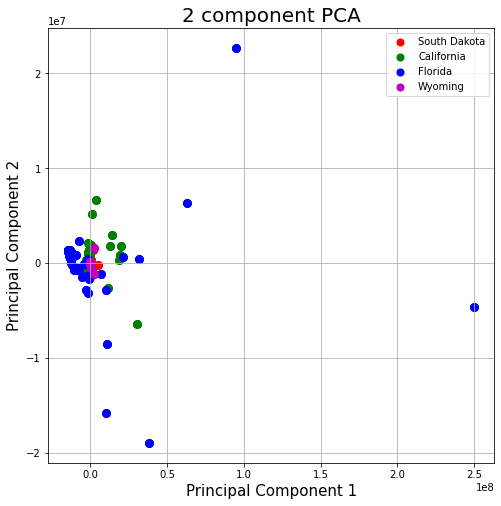

```python
########## Visualize result #########
fig = plt.figure(figsize = (8,8))
ax = fig.add_subplot(1,1,1)
ax.set_xlabel('Principal Component 1', fontsize = 15)
ax.set_ylabel('Principal Component 2', fontsize = 15)
ax.set_title('2 component PCA', fontsize = 20)
targets = ['South Dakota', 'California', 'Florida','Wyoming']
colors = ['r', 'g', 'b','m']
for target, color in zip(targets,colors):
    indicesToKeep = df_final['target'] == target
    ax.scatter(df_final.loc[indicesToKeep, 'principal component 1']
               , df_final.loc[indicesToKeep, 'principal component 2']
               , c = color
               , s = 50)
ax.legend(targets)
ax.grid()
```

# Using SVD for dimension reduction

```
     principal component 1  principal component 2  state_California  \
0           -231356.258607           19563.443385                 0
1           -231356.261503           19563.441495                 0
2           -231356.277710           19563.430924                 0
3           -231356.274527           19563.433000                 0
4           -231356.323444           19563.401092                 0
..                     ...                    ...               ...
478         -355885.167669           -4257.692372                 0
479         -355885.169066           -4257.694599                 0
480         -355885.168249           -4257.693298                 0
481         -355885.168564           -4257.693798                 0
482         -355885.169476           -4257.695249                 0

     state_Florida  state_South Dakota  state_Wyoming
0                0                   1              0
1                0                   1              0
2                0                   1              0
3                0                   1              0
4                0                   1              0
..             ...                 ...            ...
478              0                   0              1
479              0                   0              1
480              0                   0              1
481              0                   0              1
482              0                   0              1

[4452 rows x 6 columns]
```

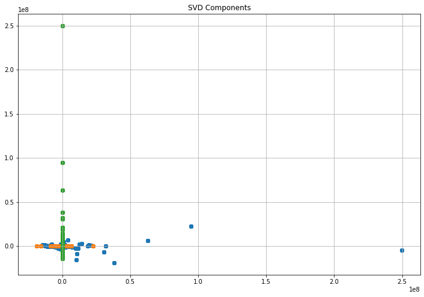

```python
from sklearn.decomposition import TruncatedSVD

df_final = pd.get_dummies(df_final, prefix='state', columns=["target"], drop_first=False)
print(df_final)
svd = TruncatedSVD(n_components=4, random_state=42).fit_transform(df_final.values)
plt.figure(figsize=(12,8))
plt.title('SVD Components')
plt.scatter(svd[:,0], svd[:,1])
plt.scatter(svd[:,1], svd[:,2])
plt.scatter(svd[:,2],svd[:,0])






# specify colors for each state
# color_dict = dict({'South Dakota':'Black',
#                    'Europe': 'Red',
#                    'Florida':'Blue',
#                    'Wyoming':'Green'})
# # Scatter plot: SV1 and SV2
# sns.scatterplot(x="SV1", y="SV2", hue="State",
#                 palette=color_dict,
#                 data=df_final, s=100,
#                 alpha=0.7)
# plt.xlabel('SV 1:', fontsize=16)
# plt.ylabel('SV 2:', fontsize=16)
plt.grid()
plt.show()
```

# Section C

Voter turnout – in political science, voter turnout is the percentage of registered voters who participated in an election (often defined as those who cast a ballot).

```python
# get total number of district per state

def return_value(x):
    if(list(set(x))[0] == 0):
        return 0
    else:
        return len(list(set(x)))

df_house_dis = df_house[['year','state','district']]
df_house_group_with_number_of_district = df_house_dis.groupby(by=['year','state'],as_index=False).agg(lambda x: return_value(x))
df_house_group_with_number_of_district
```

|  | year | state | district |
| --- | --- | --- | --- |
| 0 | 1976 | ALABAMA | 7 |
| 1 | 1976 | ALASKA | 0 |
| 2 | 1976 | ARIZONA | 4 |
| 3 | 1976 | ARKANSAS | 4 |
| 4 | 1976 | CALIFORNIA | 43 |
| ... | ... | ... | ... |
| 1146 | 2020 | VIRGINIA | 11 |
| 1147 | 2020 | WASHINGTON | 10 |
| 1148 | 2020 | WEST VIRGINIA | 3 |
| 1149 | 2020 | WISCONSIN | 8 |
| 1150 | 2020 | WYOMING | 0 |

1151 rows × 3 columns

```python
def return_value(x):
    if(isinstance(list(x)[0], (int, np.integer))):
        return sum(list((x)))
    else:
        if(len(set(x)) ==1):
            return list(x)[0]
        else:
            return list(set(x))

df_house_group = df_house.groupby(by=['year','state'],as_index=False).agg(lambda x: return_value(x))
df_house_group.drop(['state_cen','state_ic','state_fips','district','totalvotes','version','candidate'], axis=1, inplace=True)
df_house_group.rename(columns = {'candidatevotes':'totalvotes'}, inplace = True)
df_house_group
```

|  | year | state | state_po | office | stage | runoff | special | party | writein | mode | totalvotes | unofficial | fusion_ticket |
| --- | --- | --- | --- | --- | --- | --- | --- | --- | --- | --- | --- | --- | --- |
| 0 | 1976 | ALABAMA | AL | US HOUSE | GEN | 0.0 | 0 | [nan, DEMOCRAT, PROHIBITION, REPUBLICAN, NATIO... | 6 | TOTAL | 984181 | 0 | 0 |
| 1 | 1976 | ALASKA | AK | US HOUSE | GEN | 0.0 | 0 | [nan, REPUBLICAN, DEMOCRAT] | 1 | TOTAL | 118208 | 0 | 0 |
| 2 | 1976 | ARIZONA | AZ | US HOUSE | GEN | 0.0 | 0 | [INDEPENDENT, REPUBLICAN, DEMOCRAT, LIBERTARIAN] | 0 | TOTAL | 729002 | 0 | 0 |
| 3 | 1976 | ARKANSAS | AR | US HOUSE | GEN | 0.0 | 0 | [nan, REPUBLICAN, DEMOCRAT] | 1 | TOTAL | 336391 | 0 | 0 |
| 4 | 1976 | CALIFORNIA | CA | US HOUSE | GEN | 0.0 | 0 | [AMERICAN INDEPENDENT, DEMOCRAT, INDEPENDENT, ... | 0 | TOTAL | 7442501 | 0 | 0 |
| ... | ... | ... | ... | ... | ... | ... | ... | ... | ... | ... | ... | ... | ... |
| 1146 | 2020 | VIRGINIA | VA | US HOUSE | GEN | 0.0 | 0 | [nan, INDEPENDENT, REPUBLICAN, DEMOCRAT] | 11 | TOTAL | 4335436 | 0 | 2 |
| 1147 | 2020 | WASHINGTON | WA | US HOUSE | GEN | 0.0 | 0 | [nan, REPUBLICAN, DEMOCRAT] | 10 | TOTAL | 3944233 | 0 | 0 |
| 1148 | 2020 | WEST VIRGINIA | WV | US HOUSE | GEN | 0.0 | 0 | [REPUBLICAN, DEMOCRAT, WRITE-IN] | 0 | TOTAL | 761385 | 0 | 0 |
| 1149 | 2020 | WISCONSIN | WI | US HOUSE | GEN | 0.0 | 0 | [nan, INDEPENDENT, REPUBLICAN, DEMOCRAT] | 8 | TOTAL | 3238051 | 0 | 0 |
| 1150 | 2020 | WYOMING | WY | US HOUSE | GEN | 0.0 | 0 | [nan, CONSTITUTION, DEMOCRAT, LIBERTARIAN, REP... | 1 | TOTAL | 278503 | 0 | 0 |

1151 rows × 13 columns

```python
# add the number of district to table
df_house_group= pd.merge(left = df_house_group, right = df_house_group_with_number_of_district, how = 'inner' , on = ['year','state'])
df_house_group
```

|  | year | state | state_po | office | stage | runoff | special | party | writein | mode | totalvotes | unofficial | fusion_ticket | district |
| --- | --- | --- | --- | --- | --- | --- | --- | --- | --- | --- | --- | --- | --- | --- |
| 0 | 1976 | ALABAMA | AL | US HOUSE | GEN | 0.0 | 0 | [nan, DEMOCRAT, PROHIBITION, REPUBLICAN, NATIO... | 6 | TOTAL | 984181 | 0 | 0 | 7 |
| 1 | 1976 | ALASKA | AK | US HOUSE | GEN | 0.0 | 0 | [nan, REPUBLICAN, DEMOCRAT] | 1 | TOTAL | 118208 | 0 | 0 | 0 |
| 2 | 1976 | ARIZONA | AZ | US HOUSE | GEN | 0.0 | 0 | [INDEPENDENT, REPUBLICAN, DEMOCRAT, LIBERTARIAN] | 0 | TOTAL | 729002 | 0 | 0 | 4 |
| 3 | 1976 | ARKANSAS | AR | US HOUSE | GEN | 0.0 | 0 | [nan, REPUBLICAN, DEMOCRAT] | 1 | TOTAL | 336391 | 0 | 0 | 4 |
| 4 | 1976 | CALIFORNIA | CA | US HOUSE | GEN | 0.0 | 0 | [AMERICAN INDEPENDENT, DEMOCRAT, INDEPENDENT, ... | 0 | TOTAL | 7442501 | 0 | 0 | 43 |
| ... | ... | ... | ... | ... | ... | ... | ... | ... | ... | ... | ... | ... | ... | ... |
| 1146 | 2020 | VIRGINIA | VA | US HOUSE | GEN | 0.0 | 0 | [nan, INDEPENDENT, REPUBLICAN, DEMOCRAT] | 11 | TOTAL | 4335436 | 0 | 2 | 11 |
| 1147 | 2020 | WASHINGTON | WA | US HOUSE | GEN | 0.0 | 0 | [nan, REPUBLICAN, DEMOCRAT] | 10 | TOTAL | 3944233 | 0 | 0 | 10 |
| 1148 | 2020 | WEST VIRGINIA | WV | US HOUSE | GEN | 0.0 | 0 | [REPUBLICAN, DEMOCRAT, WRITE-IN] | 0 | TOTAL | 761385 | 0 | 0 | 3 |
| 1149 | 2020 | WISCONSIN | WI | US HOUSE | GEN | 0.0 | 0 | [nan, INDEPENDENT, REPUBLICAN, DEMOCRAT] | 8 | TOTAL | 3238051 | 0 | 0 | 8 |
| 1150 | 2020 | WYOMING | WY | US HOUSE | GEN | 0.0 | 0 | [nan, CONSTITUTION, DEMOCRAT, LIBERTARIAN, REP... | 1 | TOTAL | 278503 | 0 | 0 | 0 |

1151 rows × 14 columns

```python
def return_value(x):
    if(isinstance(list(x)[0], (int, np.integer))):
        return sum(list((x)))
    else:
        if(len(set(x)) ==1):
            return list(x)[0]
        else:
            return list(set(x))

df_president_group = df_president.groupby(by=['year','state'],as_index=False).sum()
df_president_group = df_president_group[['year','state','candidatevotes']]
df_president_group
```

|  | year | state | candidatevotes |
| --- | --- | --- | --- |
| 0 | 1976 | ALABAMA | 1182850 |
| 1 | 1976 | ALASKA | 123574 |
| 2 | 1976 | ARIZONA | 742719 |
| 3 | 1976 | ARKANSAS | 767535 |
| 4 | 1976 | CALIFORNIA | 7803770 |
| ... | ... | ... | ... |
| 607 | 2020 | VIRGINIA | 4460524 |
| 608 | 2020 | WASHINGTON | 4087631 |
| 609 | 2020 | WEST VIRGINIA | 794652 |
| 610 | 2020 | WISCONSIN | 3298041 |
| 611 | 2020 | WYOMING | 278503 |

612 rows × 3 columns

1. Added a feature of land area --> we might see some trends in big landed areas. Useful to understand if in big areas the voting distribtution is uniform or rather different.
1. Added feature of water area that stands for --> – the area in square kilometers that is covered by water all year long.

We think that maybe the closeness to water resources might lead to vote to some candidate. As we know water is a place then might be a good place for tourism or shipping. Those results might help us to get a better overview conducting this feature too.

1. Added the popultaion as a feature to indicate if the size of the population may lead to unidormic voting. We estimate that this phenomena might occure due to the strict rules in big states.

• Population – population estimates for the county in 1990.

1. water_Area_divided_by_land --> try to fine some pattern by the relationship within the amount of land area to the amount of water area within some country in the data frame
1. land_by_population --> find the density of the population in a given country and see how that may effect the results of the election.

We might assume that more dense areas may lead to group voting.

1. water by population --> we may suggest that in a given area there might be some lack of resources that may lead to vote for some candidate with is more liberal and thinks about the poor people. In the other hand we can check if countries with a lot of water (is a resource) may vote to a leader that believes in a free market spirit.

```python
df_house_president = pd.merge(left = df_house_group, right = df_president_group, how = 'inner' , on = ['year','state'])
df_house_president.rename(columns = {'totalvotes':'totalvotes_house','candidatevotes':'totalvote_president'}, inplace = True)
df_house_president['Voter_Turnout'] = None #add new column
df_house_president['Voter_Turnout'] = pd.to_numeric(df_house_president['Voter_Turnout'],downcast='float')

df_house_president['land_area'] = None #add new column
df_house_president['land_area'] = pd.to_numeric(df_county_data['Land Area'],downcast='float')


df_house_president['water_Area'] = None #add new column
df_house_president['water_Area'] = pd.to_numeric(df_county_data['Water Area'],downcast='float')

df_house_president['population'] = None #add new column
df_house_president['population'] = pd.to_numeric(df_county_data['Population'],downcast='float')


df_house_president['water_Area_divided_by_land'] = None #add new column
df_house_president['water_Area_divided_by_land'] = pd.to_numeric(df_county_data['Water Area'],downcast='float')

for row in df_house_president.itertuples():
    df_house_president.at[row[0],'water_Area_divided_by_land'] = float(row[18]/row[17])#  water area / land area



df_house_president['land_by_population'] = None #add new column
df_house_president['land_by_population'] = pd.to_numeric(df_county_data['Land Area'],downcast='float')

for row in df_house_president.itertuples():
    df_house_president.at[row[0],'land_by_population'] = float(row[17]/row[19]) #  labd area / population


df_house_president['water_by_population'] = None #add new column
df_house_president['water_by_population'] = pd.to_numeric(df_county_data['Land Area'],downcast='float')

for row in df_house_president.itertuples():
    df_house_president.at[row[0],'water_by_population'] = float(row[18]/row[19]) #  water area / population




for col in df_house_president.itertuples():
    df_house_president.at[col[0],'Voter_Turnout'] = float(col[11]/col[15]) #total house vote / total persident vote on this state

df_house_president
```

|  | year | state | state_po | office | stage | runoff | special | party | writein | mode | ... | fusion_ticket | district | totalvote_president | Voter_Turnout | land_area | water_Area | population | water_Area_divided_by_land | land_by_population | water_by_population |
| --- | --- | --- | --- | --- | --- | --- | --- | --- | --- | --- | --- | --- | --- | --- | --- | --- | --- | --- | --- | --- | --- |
| 0 | 1976 | ALABAMA | AL | US HOUSE | GEN | 0.0 | 0 | [nan, DEMOCRAT, PROHIBITION, REPUBLICAN, NATIO... | 6 | TOTAL | ... | 0 | 7 | 1182850 | 0.832042 | 1543.699951 | 22.000000 | 34222.0 | 0.014251 | 0.045108 | 0.000643 |
| 1 | 1976 | ALASKA | AK | US HOUSE | GEN | 0.0 | 0 | [nan, REPUBLICAN, DEMOCRAT] | 1 | TOTAL | ... | 0 | 0 | 123574 | 0.956577 | 4135.000000 | 1115.099976 | 98280.0 | 0.269674 | 0.042074 | 0.011346 |
| 2 | 1976 | ARIZONA | AZ | US HOUSE | GEN | 0.0 | 0 | [INDEPENDENT, REPUBLICAN, DEMOCRAT, LIBERTARIAN] | 0 | TOTAL | ... | 0 | 4 | 742719 | 0.981531 | 2292.100098 | 50.700001 | 25417.0 | 0.022119 | 0.090180 | 0.001995 |
| 3 | 1976 | ARKANSAS | AR | US HOUSE | GEN | 0.0 | 0 | [nan, REPUBLICAN, DEMOCRAT] | 1 | TOTAL | ... | 0 | 4 | 767535 | 0.438274 | 1611.900024 | 8.100000 | 16576.0 | 0.005025 | 0.097243 | 0.000489 |
| 4 | 1976 | CALIFORNIA | CA | US HOUSE | GEN | 0.0 | 0 | [AMERICAN INDEPENDENT, DEMOCRAT, INDEPENDENT, ... | 0 | TOTAL | ... | 0 | 43 | 7803770 | 0.953706 | 1672.300049 | 12.900000 | 39248.0 | 0.007714 | 0.042609 | 0.000329 |
| ... | ... | ... | ... | ... | ... | ... | ... | ... | ... | ... | ... | ... | ... | ... | ... | ... | ... | ... | ... | ... | ... |
| 596 | 2020 | VIRGINIA | VA | US HOUSE | GEN | 0.0 | 0 | [nan, INDEPENDENT, REPUBLICAN, DEMOCRAT] | 11 | TOTAL | ... | 2 | 11 | 4460524 | 0.971957 | 956.299988 | 20.200001 | 20539.0 | 0.021123 | 0.046560 | 0.000983 |
| 597 | 2020 | WASHINGTON | WA | US HOUSE | GEN | 0.0 | 0 | [nan, REPUBLICAN, DEMOCRAT] | 10 | TOTAL | ... | 0 | 10 | 4087631 | 0.964919 | 1557.000000 | 45.000000 | 21821.0 | 0.028902 | 0.071353 | 0.002062 |
| 598 | 2020 | WEST VIRGINIA | WV | US HOUSE | GEN | 0.0 | 0 | [REPUBLICAN, DEMOCRAT, WRITE-IN] | 0 | TOTAL | ... | 0 | 3 | 794652 | 0.958136 | 896.200012 | 7.400000 | 11347.0 | 0.008257 | 0.078981 | 0.000652 |
| 599 | 2020 | WISCONSIN | WI | US HOUSE | GEN | 0.0 | 0 | [nan, INDEPENDENT, REPUBLICAN, DEMOCRAT] | 8 | TOTAL | ... | 0 | 8 | 3298041 | 0.981810 | 1348.599976 | 8.900000 | 317471.0 | 0.006599 | 0.004248 | 0.000028 |
| 600 | 2020 | WYOMING | WY | US HOUSE | GEN | 0.0 | 0 | [nan, CONSTITUTION, DEMOCRAT, LIBERTARIAN, REP... | 1 | TOTAL | ... | 0 | 0 | 278503 | 1.000000 | 1754.699951 | 10.300000 | 96255.0 | 0.005870 | 0.018230 | 0.000107 |

601 rows × 22 columns

```python
for col in df_house_president.itertuples():
    print(col[2])
```

```
ALABAMA
ALASKA
ARIZONA
ARKANSAS
CALIFORNIA
COLORADO
CONNECTICUT
DELAWARE
FLORIDA
GEORGIA
HAWAII
IDAHO
ILLINOIS
INDIANA
IOWA
KANSAS
KENTUCKY
LOUISIANA
MAINE
MARYLAND
MASSACHUSETTS
MICHIGAN
MINNESOTA
MISSISSIPPI
MISSOURI
MONTANA
NEBRASKA
NEVADA
NEW HAMPSHIRE
NEW JERSEY
NEW MEXICO
NEW YORK
NORTH CAROLINA
NORTH DAKOTA
OHIO
OKLAHOMA
OREGON
PENNSYLVANIA
RHODE ISLAND
SOUTH CAROLINA
```

[output cut: 546 more lines]

```
OKLAHOMA
OREGON
PENNSYLVANIA
RHODE ISLAND
SOUTH CAROLINA
SOUTH DAKOTA
TENNESSEE
TEXAS
UTAH
VERMONT
VIRGINIA
WASHINGTON
WEST VIRGINIA
WISCONSIN
WYOMING
```

### Removing features with non informative value such as: office,state_po,stage,party,mode

```python
Section_C = df_house_president.loc[(df_house_president['year'] < 2013) & (df_house_president['year'] > 1995)]
Section_C = pd.get_dummies(Section_C, prefix='state', columns=["state"], drop_first=False)
Section_C  = Section_C.dropna()
Section_C  = Section_C.drop(columns=['office','state_po','stage','party','mode'])
Section_C
# print(Section_C.columns)



Section_C_2012 = df_house_president.loc[(df_house_president['year'] ==2012)]

Section_C_2012 = pd.get_dummies(Section_C_2012, prefix='state', columns=["state"], drop_first=False)
Section_C_2012  = Section_C_2012.drop(columns=['runoff','office','state_po','stage','party','mode','unofficial','special','fusion_ticket'])
Section_C_2012  = Section_C_2012.dropna()

Section_C_2012_california = Section_C_2012.loc[(Section_C_2012['state_CALIFORNIA'] ==0)]
# print(Section_C_2010_california['state_CALIFORNIA']) # show california state in the df {voted once as a country} obviously.

Section_C_2012_florida = Section_C_2012.loc[(Section_C_2012['state_FLORIDA'] ==0)]
# print(Section_C_2012_florida['state_FLORIDA']) # show state_FLORIDA state in the df {voted once as a country} obviously.

Section_C_2012_south_dakota = Section_C_2012.loc[(Section_C_2012['state_SOUTH DAKOTA'] ==0)]
# print(Section_C_2012_south_dakota['state_SOUTH DAKOTA']) # show state_SOUTH DAKOTA state in the df {voted once as a country} obviously.

Section_C_2012_wyoming = Section_C_2012.loc[(Section_C_2012['state_WYOMING'] ==0)]
# print(Section_C_2012_wyoming) # show Section_C_2012_south_wyoming state in the df {voted once as a country} obviously.

target_wyoming=Section_C_2012_wyoming['Voter_Turnout']
# print(target_wyoming)

target_california=Section_C_2012_california['Voter_Turnout']
# print(target_california)

target_florida=Section_C_2012_florida['Voter_Turnout']
# print(target_florida)

target_south_dakota=Section_C_2012_south_dakota['Voter_Turnout']
# print(target_south_dakota)
```

# voter turnout = regression target

```python
y_Section_C = Section_C.loc[:, ['Voter_Turnout']]
Section_C = Section_C.drop(columns=['Voter_Turnout'])
X_Section_C = Section_C
print('features:\n',X_Section_C)
print('Target:\n',y_Section_C)
```

```
features:
      year  runoff  special  writein  totalvotes_house  unofficial  \
250  1996     0.0        0        7           1468693           0
251  1996     0.0        0        1            233700           0
252  1996     0.0        0        0           1356446           0
253  1996     0.0        0        1            863318           0
254  1996     0.0        0        0           9480738           0
..    ...     ...      ...      ...               ...         ...
395  2004     0.0        0       11           3004007           0
396  2004     0.0        0        0           2729995           0
397  2004     0.0        0        0            721656           0
398  2004     0.0        0        0           2820613           0
399  2004     0.0        0        1            239163           0

     fusion_ticket  district  totalvote_president     land_area  ...  \
```

[output cut: 67 more lines]

# Train Test split:

```python
X_train_Section_C, X_test_Section_C, y_train_Section_C, y_test_Section_C = train_test_split(X_Section_C, y_Section_C, random_state=0, train_size = .75)
```

implementation include parameter tuning. we Provide feature importance for each model.

We will compare models accuracy

# 1. Random Forest Regressor - Regressor

```python
# define model
rf = RandomForestRegressor(n_jobs=-1, random_state=10)

# define parameter grid
parameters_grid = {
    'max_depth': [3, 5],
    'min_samples_leaf': [2, 8],
    'n_estimators': [20, 50],
    'max_features': [2, 4]
}

# define grid search
grid_search = GridSearchCV(estimator=rf, param_grid=parameters_grid, cv=10)

# fit estimator
grid_search.fit(X_train_Section_C, y_train_Section_C)

# get best estimator
best = grid_search.best_estimator_
# predict
y_pred = best.predict(X_test_Section_C)
# calculate MSE
MSE = round(mean_squared_error(y_test_Section_C, y_pred), 3)
print('MSE :',MSE)
df_C = pd.DataFrame([MSE]).T
df_C = df_C.rename(index={0: 'Random Forest Regressor'}, columns={0: 'MSE'})

# get feature importance
imp = pd.DataFrame(grid_search.best_estimator_.fit(X_train_Section_C, y_train_Section_C).feature_importances_,
                   index=X_train_Section_C.columns, columns=['Importance']).sort_values('Importance')
```

```
MSE : 0.003
```

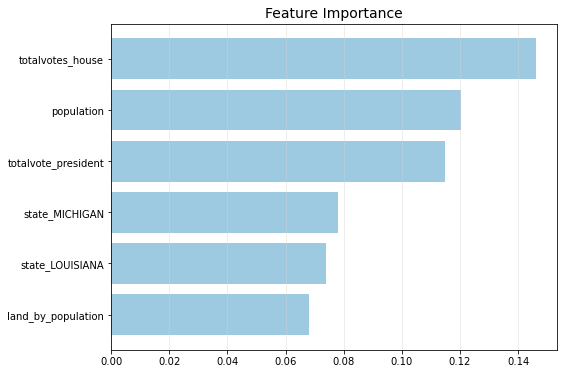

```python
# plot feature importance

plot_df=imp.tail(6)



plt.figure(figsize=(8, 6))
plt.barh(range(0, len(plot_df)), plot_df['Importance'], color='#9ecae1')
plt.grid(axis='x', alpha=0.5, color='lightgrey')
plt.yticks(range(0, len(plot_df)), plot_df.index)
plt.title('Feature Importance', fontsize=14)
plt.show()
```

# 2. GRADIENT BOOSTING - Regressor

```python
# define model
gb = GradientBoostingRegressor(random_state=RSEED)

# define parameter grid
parameters_grid = {
    'learning_rate': [0.5, 1, 1.5],
    'n_estimators': [50, 100]
}

# define grid search
grid_search = GridSearchCV(estimator=gb, param_grid=parameters_grid, cv=10)

# fit estimator
grid_search.fit(X_train_Section_C, y_train_Section_C)

# get best estimator
best = grid_search.best_estimator_

# print best parameters
pd.DataFrame.from_dict(grid_search.best_params_, orient='index', columns=['Selected Value']).T

# predict
y_pred = best.predict(X_test_Section_C)

# calculate MSE
MSE = round(mean_squared_error(y_test_Section_C, y_pred), 3)

df = pd.DataFrame([MSE]).T
df = df.rename(index={0: 'Gradient Boosting Regressor'}, columns={0: 'MSE'})
print(df)

imp = pd.DataFrame(grid_search.best_estimator_.fit(X_train_Section_C, y_train_Section_C).feature_importances_,
                   index=X_train_Section_C.columns, columns=['Importance']).sort_values('Importance')
```

```
                               MSE
Gradient Boosting Regressor  0.002
```

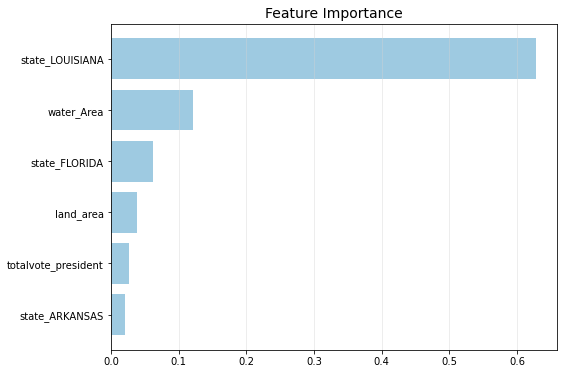

```python
plot_df=imp.tail(6)


plt.figure(figsize=(8, 6))
plt.barh(range(0, len(plot_df)), plot_df['Importance'], color='#9ecae1')
plt.grid(axis='x', alpha=0.5, color='lightgrey')
plt.yticks(range(0, len(plot_df)), plot_df.index)
plt.title('Feature Importance', fontsize=14)
plt.show()
```

# 3. Adaboost - Regressor

```python
# define model
ab = AdaBoostRegressor(random_state=RSEED)

# define parameter grid
parameters_grid = {
    'n_estimators': [20, 50]
}

# define grid search
grid_search = GridSearchCV(estimator=ab, param_grid=parameters_grid, cv=10)

# fit estimator
grid_search.fit(X_train_Section_C, y_train_Section_C)

# get best estimator
best = grid_search.best_estimator_

# print best parameters
pd.DataFrame.from_dict(grid_search.best_params_, orient='index', columns=['Selected Value']).T

# predict
y_pred = best.predict(X_test_Section_C)

# calculate MSE
MSE = round(mean_squared_error(y_test_Section_C, y_pred), 3)

df = pd.DataFrame([MSE]).T
df = df.rename(index={0: 'AdaBoost Regressor'}, columns={0: 'MSE'})
print(df)

imp = pd.DataFrame(grid_search.best_estimator_.fit(X_train_Section_C, y_train_Section_C).feature_importances_,
                   index=X_train_Section_C.columns, columns=['Importance']).sort_values('Importance')
```

```
                      MSE
AdaBoost Regressor  0.002
```

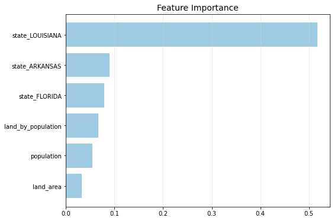

```python
plot_df=imp.tail(6)



plt.figure(figsize=(8, 6))
plt.barh(range(0, len(plot_df)), plot_df['Importance'], color='#9ecae1')
plt.grid(axis='x', alpha=0.5, color='lightgrey')
plt.yticks(range(0, len(plot_df)), plot_df.index)
plt.title('Feature Importance', fontsize=14)
plt.show()
```

By comparing the models performence we get a low MSE value. We might face over fittig to our models.

the lower the value the better and 0 means the model is perfect.

We might want to use more data to perform a larger range of results.

Or doing iterativley more models with different data, create a avg of those models for each kind {reduce over fitting}.